# Machine Learning Workflow: Boosting for Prediction

Biostat 212A

Author

Dr. Jin Zhou @ UCLA

Published

February 26, 2024

Display system information for reproducibility.

**Python**

```python
import IPython
print(IPython.sys_info())
```

```
{'commit_hash': '37242ba43',
 'commit_source': 'installation',
 'default_encoding': 'utf-8',
 'ipython_path': '/Users/jzhou/anaconda3/lib/python3.11/site-packages/IPython',
 'ipython_version': '8.12.0',
 'os_name': 'posix',
 'platform': 'macOS-14.2.1-arm64-arm-64bit',
 'sys_executable': '/Users/jzhou/anaconda3/bin/python3.11',
 'sys_platform': 'darwin',
 'sys_version': '3.11.3 (main, Apr 19 2023, 18:54:16) [Clang 14.0.6 ]'}
```

## 1 Overview

[figure not shown]

## 2 Hitters data

A documentation of the `Hitters` data is [here](https://www.rdocumentation.org/packages/ISLR2/versions/1.3-2/topics/Hitters). The goal is to predict the log(Salary) (at opening of 1987 season) of MLB players from their performance metrics in the 1986-7 season.

**R**

- There are 59 `NA`s for the salary. Let’s drop those cases. We are left with 263 data points.

```r
library(GGally)
library(gtsummary)
library(ranger)
library(tidyverse)
library(tidymodels)
library(ISLR2)

# Numerical summaries stratified by the outcome `AHD`.
Hitters %>% tbl_summary()
```

| **Characteristic** | **N = 322**<sup>1</sup> |
| --- | --- |
| AtBat | 380 (255, 512) |
| Hits | 96 (64, 137) |
| HmRun | 8 (4, 16) |
| Runs | 48 (30, 69) |
| RBI | 44 (28, 65) |
| Walks | 35 (22, 53) |
| Years | 6 (4, 11) |
| CAtBat | 1,928 (817, 3,924) |
| CHits | 508 (209, 1,059) |
| CHmRun | 38 (14, 90) |
| CRuns | 247 (100, 526) |
| CRBI | 221 (89, 426) |
| CWalks | 171 (67, 339) |
| League |  |
| A | 175 (54%) |
| N | 147 (46%) |
| Division |  |
| E | 157 (49%) |
| W | 165 (51%) |
| PutOuts | 212 (109, 325) |
| Assists | 40 (7, 166) |
| Errors | 6 (3, 11) |
| Salary | 425 (190, 750) |
| Unknown | 59 |
| NewLeague |  |
| A | 176 (55%) |
| N | 146 (45%) |

<sup>1</sup> Median (IQR); n (%)

```r
Hitters <- Hitters %>% filter(!is.na(Salary)) %>%
  select(Salary, Assists,
         AtBat, Hits, HmRun,
         PutOuts, RBI, Runs, Walks, Years)
```

**Python**

```python
# Load the pandas library
import pandas as pd
# Load numpy for array manipulation
import numpy as np
# Load seaborn plotting library
import seaborn as sns
import matplotlib.pyplot as plt

# Set font sizes in plots
sns.set(font_scale = 1.2)
# Display all columns
pd.set_option('display.max_columns', None)

Hitters = pd.read_csv("../data/Hitters.csv")
Hitters
```

```
     AtBat  Hits  HmRun  Runs  RBI  Walks  Years  CAtBat  CHits  CHmRun  \
0      293    66      1    30   29     14      1     293     66       1
1      315    81      7    24   38     39     14    3449    835      69
2      479   130     18    66   72     76      3    1624    457      63
3      496   141     20    65   78     37     11    5628   1575     225
4      321    87     10    39   42     30      2     396    101      12
..     ...   ...    ...   ...  ...    ...    ...     ...    ...     ...
317    497   127      7    65   48     37      5    2703    806      32
318    492   136      5    76   50     94     12    5511   1511      39
319    475   126      3    61   43     52      6    1700    433       7
320    573   144      9    85   60     78      8    3198    857      97
321    631   170      9    77   44     31     11    4908   1457      30

     CRuns  CRBI  CWalks League Division  PutOuts  Assists  Errors  Salary  \
0       30    29      14      A        E      446       33      20     NaN
```

[output cut: 25 more lines]

```python
# Numerical summaries
Hitters.describe()
```

```
            AtBat        Hits       HmRun        Runs         RBI       Walks  \
count  322.000000  322.000000  322.000000  322.000000  322.000000  322.000000
mean   380.928571  101.024845   10.770186   50.909938   48.027950   38.742236
std    153.404981   46.454741    8.709037   26.024095   26.166895   21.639327
min     16.000000    1.000000    0.000000    0.000000    0.000000    0.000000
25%    255.250000   64.000000    4.000000   30.250000   28.000000   22.000000
50%    379.500000   96.000000    8.000000   48.000000   44.000000   35.000000
75%    512.000000  137.000000   16.000000   69.000000   64.750000   53.000000
max    687.000000  238.000000   40.000000  130.000000  121.000000  105.000000

            Years       CAtBat        CHits      CHmRun        CRuns  \
count  322.000000    322.00000   322.000000  322.000000   322.000000
mean     7.444099   2648.68323   717.571429   69.490683   358.795031
std      4.926087   2324.20587   654.472627   86.266061   334.105886
min      1.000000     19.00000     4.000000    0.000000     1.000000
25%      4.000000    816.75000   209.000000   14.000000   100.250000
50%      6.000000   1928.00000   508.000000   37.500000   247.000000
75%     11.000000   3924.25000  1059.250000   90.000000   526.250000
max     24.000000  14053.00000  4256.000000  548.000000  2165.000000

              CRBI       CWalks      PutOuts     Assists      Errors  \
count   322.000000   322.000000   322.000000  322.000000  322.000000
mean    330.118012   260.239130   288.937888  106.913043    8.040373
std     333.219617   267.058085   280.704614  136.854876    6.368359
min       0.000000     0.000000     0.000000    0.000000    0.000000
25%      88.750000    67.250000   109.250000    7.000000    3.000000
50%     220.500000   170.500000   212.000000   39.500000    6.000000
75%     426.250000   339.250000   325.000000  166.000000   11.000000
max    1659.000000  1566.000000  1378.000000  492.000000   32.000000

            Salary
count   263.000000
mean    535.925882
std     451.118681
min      67.500000
25%     190.000000
50%     425.000000
75%     750.000000
max    2460.000000
```

Graphical summary:

```python
# Graphical summaries
plt.figure()
sns.pairplot(data = Hitters);
plt.show()
```

[output not shown]

There are 59 `NA`s for the salary. Let’s drop those cases. We are left with 263 data points.

```python
Hitters.dropna(inplace = True)
Hitters.shape
```

```
(263, 20)
```

## 3 Initial split into test and non-test sets

We randomly split the data in half of test data and another half of non-test data.

**Python**

```python
from sklearn.model_selection import train_test_split

Hitters_other, Hitters_test = train_test_split(
  Hitters,
  train_size = 0.5,
  random_state = 425, # seed
  )
Hitters_test.shape
```

```
(132, 20)
```

```python
Hitters_other.shape
```

```
(131, 20)
```

Separate $X$ and $y$. We will use 9 of the features.

```python
features = ['Assists', 'AtBat', 'Hits', 'HmRun', 'PutOuts', 'RBI', 'Runs', 'Walks', 'Years']
# Non-test X and y
X_other = Hitters_other[features]
y_other = np.log(Hitters_other.Salary)
# Test X and y
X_test = Hitters_test[features]
y_test = np.log(Hitters_test.Salary)
```

## 4 Preprocessing (Python) or recipe (R)

**R**

```r
gb_recipe <-
  recipe(
    Salary ~ .,
    data = Hitters_other
  ) %>%
  # # create traditional dummy variables (not necessary for random forest in R)
  # step_dummy(all_nominal()) %>%
  step_naomit(Salary) %>%
  # zero-variance filter
  step_zv(all_numeric_predictors()) %>%
  # # center and scale numeric data (not necessary for random forest)
  # step_normalize(all_numeric_predictors()) %>%
  # estimate the means and standard deviations
  prep(training = Hitters_other, retain = TRUE)
gb_recipe
```

[output not shown]

**Python**

Not much preprocessing is needed here since all predictors are quantitative.

## 5 Model

**R**

```r
gb_mod <-
  boost_tree(
    mode = "regression",
    trees = 1000,
    tree_depth = tune(),
    learn_rate = tune()
  ) %>%
  set_engine("xgboost")
gb_mod
```

```
Boosted Tree Model Specification (regression)

Main Arguments:
  trees = 1000
  tree_depth = tune()
  learn_rate = tune()

Computational engine: xgboost
```

**Python**

```python
from sklearn.ensemble import AdaBoostRegressor
from sklearn.tree import DecisionTreeRegressor

bst_mod =  AdaBoostRegressor(
  # Default base estimator is DecisionTreeRegressor with max_depth = 3
  estimator = DecisionTreeRegressor(max_depth = 3),
  # Number of trees (to be tuned)
  n_estimators = 50,
  # Learning rate (to be tuned)
  learning_rate = 1.0,
  random_state = 425
  )
```

## 6 Pipeline (Python) or workflow (R)

Here we bundle the preprocessing step (Python) or recipe (R) and model.

**R**

```r
gb_wf <- workflow() %>%
  add_recipe(gb_recipe) %>%
  add_model(gb_mod)
gb_wf
```

```
══ Workflow ════════════════════════════════════════════════════════════════════
Preprocessor: Recipe
Model: boost_tree()

── Preprocessor ────────────────────────────────────────────────────────────────
2 Recipe Steps

• step_naomit()
• step_zv()

── Model ───────────────────────────────────────────────────────────────────────
Boosted Tree Model Specification (regression)

Main Arguments:
  trees = 1000
  tree_depth = tune()
  learn_rate = tune()

Computational engine: xgboost
```

**Python**

```python
from sklearn.pipeline import Pipeline

pipe = Pipeline(steps = [
  ("model", bst_mod)
  ])
pipe
```

```
Pipeline(steps=[('model',
                 AdaBoostRegressor(estimator=DecisionTreeRegressor(max_depth=3),
                                   random_state=425))])
```

## 7 Tuning grid

**R**

```r
param_grid <- grid_regular(
  tree_depth(range = c(1L, 4L)),
  learn_rate(range = c(-3, -0.5), trans = log10_trans()),
  levels = c(4, 10)
  )
param_grid
```

```
# A tibble: 40 × 2
   tree_depth learn_rate
        <int>      <dbl>
 1          1    0.001
 2          2    0.001
 3          3    0.001
 4          4    0.001
 5          1    0.00190
 6          2    0.00190
 7          3    0.00190
 8          4    0.00190
 9          1    0.00359
10          2    0.00359
# ℹ 30 more rows
```

**Python**

```python
# Tune hyper-parameter(s)
d_grid = [
  DecisionTreeRegressor(max_depth = 1),
  DecisionTreeRegressor(max_depth = 2),
  DecisionTreeRegressor(max_depth = 3),
  DecisionTreeRegressor(max_depth = 4)
  ]
B_grid = [50, 100, 150, 200, 250, 300, 350, 400]
lambda_grid = [0.2, 0.4, 0.6, 0.8, 1.0]
tuned_parameters = {
  "model__estimator": d_grid,
  "model__n_estimators": B_grid,
  "model__learning_rate": lambda_grid
  }
tuned_parameters
```

```
{'model__estimator': [DecisionTreeRegressor(max_depth=1), DecisionTreeRegressor(max_depth=2), DecisionTreeRegressor(max_depth=3), DecisionTreeRegressor(max_depth=4)], 'model__n_estimators': [50, 100, 150, 200, 250, 300, 350, 400], 'model__learning_rate': [0.2, 0.4, 0.6, 0.8, 1.0]}
```

## 8 Cross-validation (CV)

**R**

Set cross-validation partitions.

```r
set.seed(203)

folds <- vfold_cv(Hitters_other, v = 5)
folds
```

```
#  5-fold cross-validation
# A tibble: 5 × 2
  splits           id
  <list>           <chr>
1 <split [104/27]> Fold1
2 <split [105/26]> Fold2
3 <split [105/26]> Fold3
4 <split [105/26]> Fold4
5 <split [105/26]> Fold5
```

Fit cross-validation.

```r
gb_fit <- gb_wf %>%
  tune_grid(
    resamples = folds,
    grid = param_grid,
    metrics = metric_set(rmse, rsq)
    )
gb_fit
```

```
# Tuning results
# 5-fold cross-validation
# A tibble: 5 × 4
  splits           id    .metrics          .notes
  <list>           <chr> <list>            <list>
1 <split [104/27]> Fold1 <tibble [80 × 6]> <tibble [0 × 3]>
2 <split [105/26]> Fold2 <tibble [80 × 6]> <tibble [0 × 3]>
3 <split [105/26]> Fold3 <tibble [80 × 6]> <tibble [0 × 3]>
4 <split [105/26]> Fold4 <tibble [80 × 6]> <tibble [0 × 3]>
5 <split [105/26]> Fold5 <tibble [80 × 6]> <tibble [0 × 3]>
```

Visualize CV results:

```
# A tibble: 80 × 8
   tree_depth learn_rate .metric .estimator    mean     n std_err
        <int>      <dbl> <chr>   <chr>        <dbl> <int>   <dbl>
 1          1    0.001   rmse    standard   446.        5 61.7
 2          1    0.001   rsq     standard     0.351     5  0.0801
 3          2    0.001   rmse    standard   433.        5 57.7
 4          2    0.001   rsq     standard     0.352     5  0.0844
 5          3    0.001   rmse    standard   426.        5 58.8
 6          3    0.001   rsq     standard     0.383     5  0.0905
 7          4    0.001   rmse    standard   432.        5 61.8
 8          4    0.001   rsq     standard     0.345     5  0.0619
 9          1    0.00190 rmse    standard   395.        5 51.2
10          1    0.00190 rsq     standard     0.368     5  0.0868
   .config
   <chr>
 1 Preprocessor1_Model01
 2 Preprocessor1_Model01
 3 Preprocessor1_Model02
 4 Preprocessor1_Model02
 5 Preprocessor1_Model03
 6 Preprocessor1_Model03
 7 Preprocessor1_Model04
 8 Preprocessor1_Model04
 9 Preprocessor1_Model05
10 Preprocessor1_Model05
# ℹ 70 more rows
```

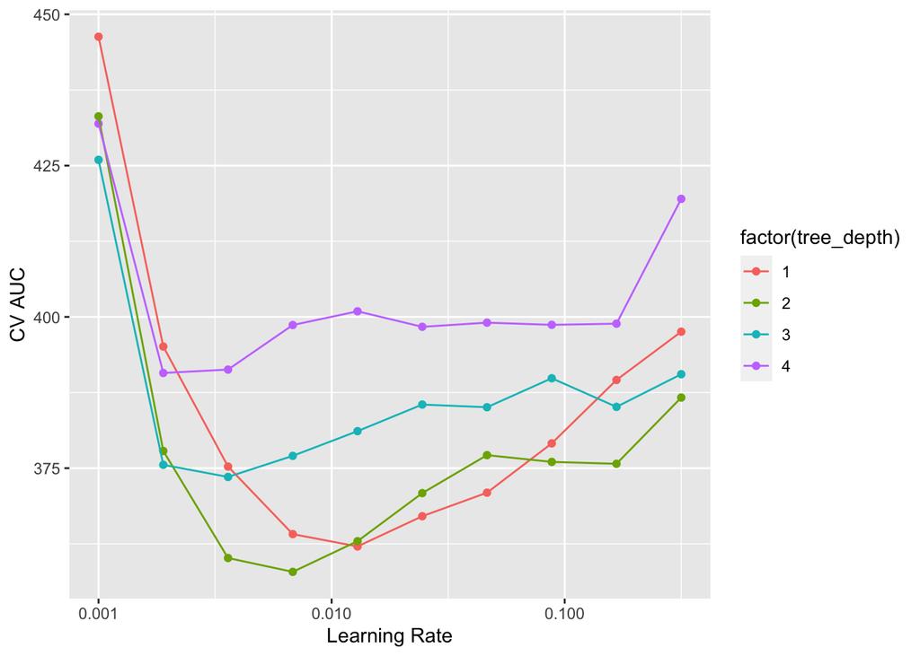

```r
gb_fit %>%
  collect_metrics() %>%
  print(width = Inf) %>%
  filter(.metric == "rmse") %>%
  ggplot(mapping = aes(x = learn_rate, y = mean, color = factor(tree_depth))) +
  geom_point() +
  geom_line() +
  labs(x = "Learning Rate", y = "CV AUC") +
  scale_x_log10()
```

Show the top 5 models.

```r
gb_fit %>%
  show_best("rmse")
```

```
# A tibble: 5 × 8
  tree_depth learn_rate .metric .estimator  mean     n std_err .config
       <int>      <dbl> <chr>   <chr>      <dbl> <int>   <dbl> <chr>
1          2    0.00681 rmse    standard    358.     5    36.5 Preprocessor1_Mo…
2          2    0.00359 rmse    standard    360.     5    35.6 Preprocessor1_Mo…
3          1    0.0129  rmse    standard    362.     5    35.4 Preprocessor1_Mo…
4          2    0.0129  rmse    standard    363.     5    39.3 Preprocessor1_Mo…
5          1    0.00681 rmse    standard    364.     5    35.4 Preprocessor1_Mo…
```

Let’s select the best model.

```r
best_gb <- gb_fit %>%
  select_best("rmse")
best_gb
```

```
# A tibble: 1 × 3
  tree_depth learn_rate .config
       <int>      <dbl> <chr>
1          2    0.00681 Preprocessor1_Model14
```

**Python**

Set up CV partitions and CV criterion.

```python
from sklearn.model_selection import GridSearchCV

# Set up CV
n_folds = 6
search = GridSearchCV(
  pipe,
  tuned_parameters,
  cv = n_folds,
  scoring = "neg_root_mean_squared_error",
  # Refit the best model on the whole data set
  refit = True
  )
```

Fit CV. This is typically the most time-consuming step.

```python
# Fit CV
search.fit(X_other, y_other)
```

```
GridSearchCV(cv=6,
             estimator=Pipeline(steps=[('model',
                                        AdaBoostRegressor(estimator=DecisionTreeRegressor(max_depth=3),
                                                          random_state=425))]),
             param_grid={'model__estimator': [DecisionTreeRegressor(max_depth=1),
                                              DecisionTreeRegressor(max_depth=2),
                                              DecisionTreeRegressor(max_depth=3),
                                              DecisionTreeRegressor(max_depth=4)],
                         'model__learning_rate': [0.2, 0.4, 0.6, 0.8, 1.0],
                         'model__n_estimators': [50, 100, 150, 200, 250, 300,
                                                 350, 400]},
             scoring='neg_root_mean_squared_error')
```

Visualize CV results.

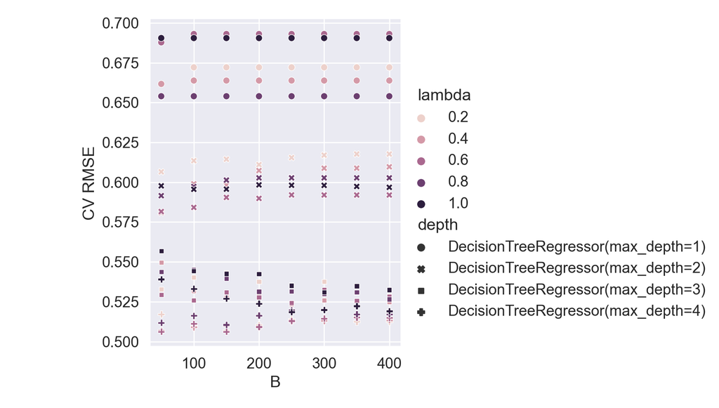

```python
cv_res = pd.DataFrame({
  "B": np.array(search.cv_results_["param_model__n_estimators"]),
  "rmse": -search.cv_results_["mean_test_score"],
  "lambda": search.cv_results_["param_model__learning_rate"],
  "depth": search.cv_results_["param_model__estimator"],
  })

plt.figure()
sns.relplot(
  # kind = "line",
  data = cv_res,
  x = "B",
  y = "rmse",
  hue = "lambda",
  style = "depth"
  ).set(
    xlabel = "B",
    ylabel = "CV RMSE"
);
plt.show()
```

Best CV RMSE:

```python
-search.best_score_
```

```
0.5062049115166872
```

## 9 Finalize our model

Now we are done tuning. Finally, let’s fit this final model to the whole training data and use our test data to estimate the model performance we expect to see with new data.

**R**

```r
# Final workflow
final_wf <- gb_wf %>%
  finalize_workflow(best_gb)
final_wf
```

```
══ Workflow ════════════════════════════════════════════════════════════════════
Preprocessor: Recipe
Model: boost_tree()

── Preprocessor ────────────────────────────────────────────────────────────────
2 Recipe Steps

• step_naomit()
• step_zv()

── Model ───────────────────────────────────────────────────────────────────────
Boosted Tree Model Specification (regression)

Main Arguments:
  trees = 1000
  tree_depth = 2
  learn_rate = 0.00681292069057962

Computational engine: xgboost
```

```r
# Fit the whole training set, then predict the test cases
final_fit <-
  final_wf %>%
  last_fit(data_split)
final_fit
```

```
# Resampling results
# Manual resampling
# A tibble: 1 × 6
  splits            id               .metrics .notes   .predictions .workflow
  <list>            <chr>            <list>   <list>   <list>       <list>
1 <split [131/132]> train/test split <tibble> <tibble> <tibble>     <workflow>
```

```r
# Test metrics
final_fit %>%
  collect_metrics()
```

```
# A tibble: 2 × 4
  .metric .estimator .estimate .config
  <chr>   <chr>          <dbl> <chr>
1 rmse    standard     292.    Preprocessor1_Model1
2 rsq     standard       0.535 Preprocessor1_Model1
```

**Python**

Since we called `GridSearchCV` with `refit = True`, the best model fit on the whole non-test data is readily available.

```python
search.best_estimator_
```

```
Pipeline(steps=[('model',
                 AdaBoostRegressor(estimator=DecisionTreeRegressor(max_depth=4),
                                   learning_rate=0.6, n_estimators=150,
                                   random_state=425))])
```

The final prediction RMSE on the test set is

```python
from sklearn.metrics import mean_squared_error

mean_squared_error(
  y_test,
  search.best_estimator_.predict(X_test),
  squared = False
  )
```

```
0.5124392035602008
```

## 10 Visualize the final model

```r
#library(rpart.plot)
final_tree <- extract_workflow(final_fit)
final_tree
```

```
══ Workflow [trained] ══════════════════════════════════════════════════════════
Preprocessor: Recipe
Model: boost_tree()

── Preprocessor ────────────────────────────────────────────────────────────────
2 Recipe Steps

• step_naomit()
• step_zv()

── Model ───────────────────────────────────────────────────────────────────────
##### xgb.Booster
raw: 848.7 Kb
call:
  xgboost::xgb.train(params = list(eta = 0.00681292069057962, max_depth = 2L,
    gamma = 0, colsample_bytree = 1, colsample_bynode = 1, min_child_weight = 1,
    subsample = 1), data = x$data, nrounds = 1000, watchlist = x$watchlist,
    verbose = 0, nthread = 1, objective = "reg:squarederror")
params (as set within xgb.train):
  eta = "0.00681292069057962", max_depth = "2", gamma = "0", colsample_bytree = "1", colsample_bynode = "1", min_child_weight = "1", subsample = "1", nthread = "1", objective = "reg:squarederror", validate_parameters = "TRUE"
xgb.attributes:
  niter
callbacks:
  cb.evaluation.log()
# of features: 9
niter: 1000
nfeatures : 9
evaluation_log:
     iter training_rmse
    <num>         <num>
        1      715.0047
        2      711.4053
---
      999      170.5347
     1000      170.4431
```

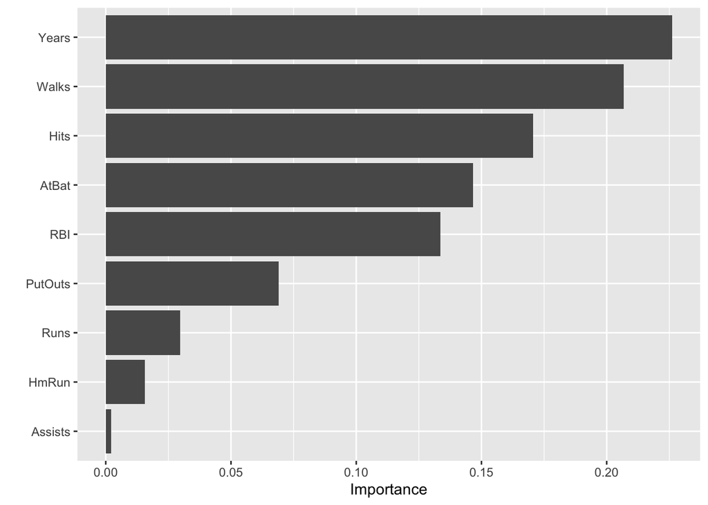

```r
library(vip)

final_tree %>%
  extract_fit_parsnip() %>%
  vip()
```